# 부동산 데이터 탐색

- 단독다가구(매매)

## 라이브러리

```python
import numpy as np
import pandas as pd
import os
import glob
```

## 데이터 불러오기

```python
path = "Dataset/HOUSE_SALE"
allFiles = glob.glob(os.path.join(path,"*.csv"))
```

```python
#allFiles
```

```python
np_array_list = []
for file_ in allFiles:
    df = pd.read_csv(file_,index_col=None,skiprows = 15, engine='python',encoding="euc-kr")
    np_array_list.append(df.as_matrix())

comb_np_array = np.vstack(np_array_list)
dataset = pd.DataFrame(comb_np_array)
dataset.columns = df.columns
```

```python
dataset.columns
```

```
Index(['시군구', '번지', '주택유형', '도로조건', '연면적(㎡)', '대지면적(㎡)', '계약년월', '계약일',
       '거래금액(만원)', '건축년도', '도로명'],
      dtype='object')
```

```python
dataset.columns = ["add_1", "add_2", "class", "road_condition",
                   "GFA", "land_area", "year_month", "day",
                   "price", "built_year", "road_name"]
```

## 전체 데이터셋 구조

### Shape

```python
dataset.shape
# 관측치 : 313,710
# 항목 : 11
```

```
(313710, 11)
```

### Head

```python
dataset.head()
```

|  | add_1 | add_2 | class | road_condition | GFA | land_area | year_month | day | price | built_year | road_name |
| --- | --- | --- | --- | --- | --- | --- | --- | --- | --- | --- | --- |
| 0 | 강원도 강릉시 교동 | 1*** | 다가구 | 12m미만 | 371.58 | 219.3 | 201512 | 1~10 | 63,000 | 2003 | 하슬라로206번길 |
| 1 | 강원도 강릉시 교동 | 7** | 단독 | 8m미만 | 122.52 | 121 | 201512 | 11~20 | 9,000 | 1985 | 화부산로117번길 |
| 2 | 강원도 강릉시 교동 | 1** | 단독 | 25m이상 | 193.29 | 156 | 201512 | 1~10 | 11,500 | 1978 | 율곡로 |
| 3 | 강원도 강릉시 교동 | 9** | 단독 | 12m미만 | 88.62 | 178.2 | 201512 | 21~31 | 11,000 | 1976 | 원대로20번길 |
| 4 | 강원도 강릉시 교동 | 1** | 단독 | 8m미만 | 81.67 | 185 | 201512 | 1~10 | 9,700 | 1982 | 강릉대로211번길 |

### Describe

- 범주형 변수 : add_1(16493), add_2(42), class(2), road_condition(5), day(6), road_name(74958)
- 이산 및 연속형 변수 : year_month(34), GFA, land_area, price, built_year

```python
dataset.describe()
```

|  | add_1 | add_2 | class | road_condition | GFA | land_area | year_month | day | price | built_year | road_name |
| --- | --- | --- | --- | --- | --- | --- | --- | --- | --- | --- | --- |
| count | 313710 | 313710 | 313710 | 313710 | 313710.0 | 313710.0 | 313710 | 313710 | 313710 | 311759.0 | 298737 |
| unique | 16493 | 42 | 2 | 5 | 51788.0 | 10077.0 | 34 | 6 | 22436 | 129.0 | 74958 |
| top | 대구광역시 남구 대명동 | 1** | 단독 | 8m미만 | 59.5 | 132.0 | 201610 | 11~20 | 20,000 | 1980.0 | 중앙로 |
| freq | 2280 | 42780 | 267381 | 223355 | 901.0 | 2249.0 | 12271 | 102903 | 3723 | 13359.0 | 586 |

### 변수 별 고유값 확인

```python
for i in range(len(dataset.columns)):
    print("="*100, "\n\n",
          "# ",list(dataset.columns)[i]," #\n\n",
          dataset[list(dataset.columns)[i]].unique(),"\n\n",
          "="*100, sep="")
```

```
====================================================================================================

# add_1 #

['강원도 강릉시 교동' '강원도 강릉시 구정면 덕현리' '강원도 강릉시 구정면 제비리' ... '충청북도 진천군 진천읍 송두리'
 '충청북도 충주시 금가면 하담리' '충청북도 충주시 살미면 공이리']

====================================================================================================
====================================================================================================

# add_2 #

['1***' '7**' '1**' '9**' '2*' '3**' '6**' '4**' '2**' '5**' '6*' '8*'
 '1*' '5*' '4*' '*' '8**' '3*' '9*' '7*' '2***' '3***' '4***' '5***'
 '6***' '7***' '산5*' '산2**' '산3*' '산9*' '산7*' '산*' '산1**' '산4*' '산2*'
 '산1*' '산6*' '산3**' '산8*' '산5**' '산1***' '산2***']

====================================================================================================
====================================================================================================

# class #

['다가구' '단독']

====================================================================================================
====================================================================================================

# road_condition #

['12m미만' '8m미만' '25m이상' '25m미만' '-']

====================================================================================================
====================================================================================================

# GFA #

[371.58 122.52 193.29 ... 481.51 717.48 366.63]

====================================================================================================
====================================================================================================
```

[output cut: 41 more lines]

```
 1930.0 1909.0 1964.0 1946.0 1915.0 1943.0 1929.0 1934.0 1936.0 1940.0
 1953.0 1947.0 1935.0 1914.0 1939.0 1937.0 1910.0 1920.0 1926.0 1941.0
 1905.0 1921.0 1932.0 1924.0 1938.0 1966.0 1928.0 1931.0 1927.0 1922.0
 1949.0 1902.0 1901.0 1933.0 1919.0 1916.0 1918.0 1923.0 1917.0 2016.0
 1903.0 1911.0 1912.0 1907.0 1904.0 1913.0 1908.0 993.0 970.0 199.0 2017.0
 987.0 998.0 994.0 977.0 2018.0 0.0 976.0 992]

====================================================================================================
====================================================================================================

# road_name #

['하슬라로206번길' '화부산로117번길' '율곡로' ... '교동11길' '사천후동길' '상방8길']

====================================================================================================
```

### price 변수 콤마 제거

```python
# "price" 변수 천 단위 표시(",") 제거 후 정수 타입으로 변환
dataset["price"] = dataset["price"].str.replace(",","").astype(int)
```

### 결측치 처리

```python
for i in range(len(dataset.columns)) :
    print(list(dataset.columns)[i],"결측치 수 :",sum(dataset[list(dataset.columns)[i]].isnull()))
```

```
add_1 결측치 수 : 0
add_2 결측치 수 : 0
class 결측치 수 : 0
road_condition 결측치 수 : 0
GFA 결측치 수 : 0
land_area 결측치 수 : 0
year_month 결측치 수 : 0
day 결측치 수 : 0
price 결측치 수 : 0
built_year 결측치 수 : 1951
road_name 결측치 수 : 14973
```

```python
# built_year 결측치 확인
dataset[dataset["built_year"].isnull()==True].head()
```

|  | add_1 | add_2 | class | road_condition | GFA | land_area | year_month | day | price | built_year | road_name |
| --- | --- | --- | --- | --- | --- | --- | --- | --- | --- | --- | --- |
| 70 | 강원도 동해시 천곡동 | 1*** | 단독 | 12m미만 | 82.83 | 241.4 | 201512 | 21~31 | 17100 | NaN | 항골길 |
| 105 | 강원도 속초시 영랑동 | 1* | 단독 | 8m미만 | 104.2 | 461 | 201512 | 11~20 | 15000 | NaN | 속초등대길 |
| 137 | 강원도 원주시 관설동 | 1*** | 다가구 | 12m미만 | 402.65 | 205.4 | 201512 | 11~20 | 45000 | NaN | 라옹정길 |
| 171 | 강원도 원주시 무실동 | 1*** | 단독 | 8m미만 | 54.55 | 595 | 201512 | 1~10 | 19100 | NaN | 무실양지길 |
| 178 | 강원도 원주시 봉산동 | 1*** | 단독 | 8m미만 | 71.58 | 173 | 201512 | 1~10 | 14680 | NaN | 봉산2길 |

```python
# built_year 결측치 대체(중앙값:1989)
dataset["built_year"][dataset["built_year"].isnull()==True] = dataset["built_year"].median()
```

```python
# road_name 결측치 확인
dataset[dataset["road_name"].isnull()==True].head()
```

|  | add_1 | add_2 | class | road_condition | GFA | land_area | year_month | day | price | built_year | road_name |
| --- | --- | --- | --- | --- | --- | --- | --- | --- | --- | --- | --- |
| 154 | 강원도 원주시 단구동 | 1*** | 다가구 | 12m미만 | 296.86 | 194.7 | 201512 | 21~31 | 31000 | 1998 | NaN |
| 172 | 강원도 원주시 무실동 | 7** | 단독 | - | 215.25 | 1077 | 201512 | 1~10 | 81000 | 2005 | NaN |
| 333 | 강원도 평창군 봉평면 평촌리 | 2** | 단독 | 8m미만 | 78.69 | 387 | 201512 | 1~10 | 1500 | 1963 | NaN |
| 362 | 강원도 홍천군 홍천읍 상오안리 | 2** | 단독 | 8m미만 | 296 | 1340 | 201512 | 21~31 | 5000 | 1996 | NaN |
| 371 | 강원도 화천군 간동면 방천리 | 1*** | 단독 | 8m미만 | 93 | 660 | 201512 | 11~20 | 3500 | 1989 | NaN |

```python
# 결측치 포함 관측치 비율 확인
print("도로명 주소 결측치 비율 : ", round(sum(dataset["road_name"].isnull()) / len(dataset), 4) * 100, "%", sep="")
print("="*50)
# 도로명 주소 결측있는 관측치와 결측없는 관측치에 대해 연속형 변수 값의 평균 비교
print("결측_GFA_평균 : ",dataset["GFA"][dataset["road_name"].isnull()==True].mean(),sep="")
print("무결_GFA_평균 : ",dataset["GFA"][dataset["road_name"].isnull()==False].mean(),sep="")
print("="*50)
print("결측_land_area_평균 : ",dataset["land_area"][dataset["road_name"].isnull()==True].mean(),sep="")
print("무결_land_area_평균 : ",dataset["land_area"][dataset["road_name"].isnull()==False].mean(),sep="")
print("="*50)
print("결측_price_평균 : ",dataset["price"][dataset["road_name"].isnull()==True].mean(),sep="")
print("무결_price_평균 : ",dataset["price"][dataset["road_name"].isnull()==False].mean(),sep="")
print("="*50)
print("결측_built_year_평균 : ",dataset["built_year"][dataset["road_name"].isnull()==True].mean(),sep="")
print("무결_built_year_평균 : ",dataset["built_year"][dataset["road_name"].isnull()==False].mean(),sep="")
```

```
도로명 주소 결측치 비율 : 4.77%
==================================================
결측_GFA_평균 : 158.81444934214974
무결_GFA_평균 : 173.22403023395808
==================================================
결측_land_area_평균 : 322.35804848727645
무결_land_area_평균 : 262.17897347834105
==================================================
결측_price_평균 : 39740.26046884392
무결_price_평균 : 40141.29863391545
==================================================
결측_built_year_평균 : 1987.4820009350165
무결_built_year_평균 : 1987.1075661869804
```

1.결측치 유무를 기준으로 두 집단 간에 각 연속형 변수 별로 통계적으로 유의미한 차이가 있는지 검정을 해볼 여지도 있지만,  
휴리스틱하게 판단해보자면 분포에 큰 차이는 없어 보인다고 판단

2.결측치를 대체하지 않고, 그냥 삭제해도 전체 데이터 손실률이 4.77% 정도로 크리티컬하게 큰 수준은 아니라고 판단

```python
# road_name 결측치 삭제
dataset = dataset[dataset["road_name"].isnull() == False]
```

### 데이터 형 변환

```python
dataset["GFA"] = dataset["GFA"].astype(float)
dataset["land_area"] = dataset["land_area"].astype(float)
dataset["year_month"] = dataset["year_month"].astype(object)
dataset["built_year"] = dataset["built_year"].astype(int)
```

```python
# 데이터 타입 확인
dataset.info()
```

```
<class 'pandas.core.frame.DataFrame'>
Int64Index: 298737 entries, 0 to 313709
Data columns (total 11 columns):
add_1             298737 non-null object
add_2             298737 non-null object
class             298737 non-null object
road_condition    298737 non-null object
GFA               298737 non-null float64
land_area         298737 non-null float64
year_month        298737 non-null object
day               298737 non-null object
price             298737 non-null int32
built_year        298737 non-null int32
road_name         298737 non-null object
dtypes: float64(2), int32(2), object(7)
memory usage: 25.1+ MB
```

## Feature Engineering

- add_1 변수를 분할하여 add_do, add_si 변수 생성

```python
# "add_1" 변수를 분할하여, "add_do", "add_si" 변수 생성
dataset['add_do'] = dataset['add_1'].apply(lambda e: e.split()[0])
dataset['add_si'] = dataset['add_1'].apply(lambda e: e.split()[1])
```

```python
# "add_2" 변수 삭제
del(dataset["add_2"])
```

```python
# dataset 컬럼 순서 변경 하여 df 데이터프레임 생성
df = dataset[["add_1", "add_do", "add_si", "road_name", "class", "road_condition", "year_month", "day",
              "GFA", "land_area", "built_year", "price"]]
```

- FAR(Floor Area Rate) 변수 생성 $$ {FAR} = {GFA \over land area} $$
- "FAR"이 1이상 이면 1, 1이하 이면, 0값을 할당(Categorical Variable)

```python
df["FAR"] = 0
df["FAR"][df["GFA"]/df["land_area"] >= 1] = 1
df["FAR"]=df["FAR"].astype("object")
```

```python
df.head()
```

|  | add_1 | add_do | add_si | road_name | class | road_condition | year_month | day | GFA | land_area | built_year | price | FAR |
| --- | --- | --- | --- | --- | --- | --- | --- | --- | --- | --- | --- | --- | --- |
| 0 | 강원도 강릉시 교동 | 강원도 | 강릉시 | 하슬라로206번길 | 다가구 | 12m미만 | 201512 | 1~10 | 371.58 | 219.3 | 2003 | 63000 | 1 |
| 1 | 강원도 강릉시 교동 | 강원도 | 강릉시 | 화부산로117번길 | 단독 | 8m미만 | 201512 | 11~20 | 122.52 | 121.0 | 1985 | 9000 | 1 |
| 2 | 강원도 강릉시 교동 | 강원도 | 강릉시 | 율곡로 | 단독 | 25m이상 | 201512 | 1~10 | 193.29 | 156.0 | 1978 | 11500 | 1 |
| 3 | 강원도 강릉시 교동 | 강원도 | 강릉시 | 원대로20번길 | 단독 | 12m미만 | 201512 | 21~31 | 88.62 | 178.2 | 1976 | 11000 | 0 |
| 4 | 강원도 강릉시 교동 | 강원도 | 강릉시 | 강릉대로211번길 | 단독 | 8m미만 | 201512 | 1~10 | 81.67 | 185.0 | 1982 | 9700 | 0 |

```python
## add_do (도/광역시/특별자치시/특별자치도/특별시)
## add_si (시/군/구)
print(df["add_do"].unique())
print("\n")
print(df["add_si"].unique())
```

```
['강원도' '경기도' '경상남도' '경상북도' '광주광역시' '대구광역시' '대전광역시' '부산광역시' '서울특별시'
 '세종특별자치시' '울산광역시' '인천광역시' '전라남도' '전라북도' '제주특별자치도' '충청남도' '충청북도']


['강릉시' '고성군' '동해시' '삼척시' '속초시' '양양군' '영월군' '원주시' '인제군' '정선군' '철원군' '춘천시'
 '태백시' '평창군' '홍천군' '화천군' '횡성군' '가평군' '고양덕양구' '고양일산동구' '고양일산서구' '과천시' '광명시'
 '광주시' '구리시' '군포시' '김포시' '남양주시' '동두천시' '부천시' '성남분당구' '성남수정구' '성남중원구'
 '수원권선구' '수원영통구' '수원장안구' '수원팔달구' '시흥시' '안산단원구' '안산상록구' '안성시' '안양동안구'
 '안양만안구' '양주시' '양평군' '여주시' '연천군' '오산시' '용인기흥구' '용인수지구' '용인처인구' '의왕시'
 '의정부시' '이천시' '파주시' '평택시' '포천시' '하남시' '화성시' '거제시' '거창군' '김해시' '남해군' '밀양시'
 '사천시' '산청군' '양산시' '의령군' '진주시' '창녕군' '창원마산합포구' '창원마산회원구' '창원성산구' '창원의창구'
 '창원진해구' '통영시' '하동군' '함안군' '함양군' '합천군' '경산시' '경주시' '고령군' '구미시' '군위군' '김천시'
 '문경시' '봉화군' '상주시' '성주군' '안동시' '영덕군' '영양군' '영주시' '영천시' '예천군' '울릉군' '울진군'
 '의성군' '청도군' '청송군' '칠곡군' '포항남구' '포항북구' '광산구' '남구' '동구' '북구' '서구' '달서구'
 '달성군' '수성구' '중구' '대덕구' '유성구' '강서구' '금정구' '기장군' '동래구' '부산진구' '사상구' '사하구'
 '수영구' '연제구' '영도구' '해운대구' '강남구' '강동구' '강북구' '관악구' '광진구' '구로구' '금천구' '노원구'
 '도봉구' '동대문구' '동작구' '마포구' '서대문구' '서초구' '성동구' '성북구' '송파구' '양천구' '영등포구'
 '용산구' '은평구' '종로구' '중랑구' '금남면' '부강면' '연기면' '연서면' '장군면' '전의면' '조치원읍' '울주군'
 '강화군' '계양구' '남동구' '미추홀구' '부평구' '연수구' '옹진군' '강진군' '고흥군' '곡성군' '광양시' '구례군'
 '나주시' '담양군' '목포시' '무안군' '보성군' '순천시' '신안군' '여수시' '영광군' '영암군' '완도군' '장성군'
 '장흥군' '진도군' '함평군' '해남군' '화순군' '고창군' '군산시' '김제시' '남원시' '무주군' '부안군' '순창군'
 '완주군' '익산시' '임실군' '장수군' '전주덕진구' '전주완산구' '정읍시' '진안군' '서귀포시' '제주시' '계룡시'
 '공주시' '금산군' '논산시' '당진시' '보령시' '부여군' '서산시' '서천군' '아산시' '예산군' '천안동남구'
 '천안서북구' '청양군' '태안군' '홍성군' '괴산군' '단양군' '보은군' '영동군' '옥천군' '음성군' '제천시' '증평군'
 '진천군' '청주상당구' '청주서원구' '청주청원구' '청주흥덕구' '충주시' '양구군' '전동면' '소정면' '연동면' '고운동']
```

## "Class" EDA

```python
print("# 빈도 \n\n",
      df["class"].value_counts(),sep="")
print("\n")
print("# 비율 \n\n",
      df["class"].value_counts(normalize=True), sep="")
```

```
# 빈도

단독     253724
다가구     45013
Name: class, dtype: int64


# 비율

단독     0.849322
다가구    0.150678
Name: class, dtype: float64
```

```python
print("# 단독 평균 거래금액(만원) \n\n",
      df["price"][df["class"]=="단독"].mean())
print("\n")
print("# 다가구 평균 거래금액(만원) \n\n",
      df["price"][df["class"]=="다가구"].mean())
```

```
# 단독 평균 거래금액(만원)

 34621.44012391417


# 다가구 평균 거래금액(만원)

 71254.98980294581
```

#### Class(단독, 다가구) 별 평균 거래금액에 큰 차이가 있으므로 데이터프레임 분리하여 분석할 필요가 있음

- 단독평균 : 3억 4천 만원
- 다가구평균 : 7억 1천 만원

```python
# "df_single" 단독 주택 데이터프레임 및 "df_multi" 다가구 주택 데이터프레임 생성
df_single = df[df["class"]=="단독"]
df_multi = df[df["class"]=="다가구"]
```

```python
df_single.head()
```

|  | add_1 | add_do | add_si | road_name | class | road_condition | year_month | day | GFA | land_area | built_year | price | FAR |
| --- | --- | --- | --- | --- | --- | --- | --- | --- | --- | --- | --- | --- | --- |
| 1 | 강원도 강릉시 교동 | 강원도 | 강릉시 | 화부산로117번길 | 단독 | 8m미만 | 201512 | 11~20 | 122.52 | 121.0 | 1985 | 9000 | 1 |
| 2 | 강원도 강릉시 교동 | 강원도 | 강릉시 | 율곡로 | 단독 | 25m이상 | 201512 | 1~10 | 193.29 | 156.0 | 1978 | 11500 | 1 |
| 3 | 강원도 강릉시 교동 | 강원도 | 강릉시 | 원대로20번길 | 단독 | 12m미만 | 201512 | 21~31 | 88.62 | 178.2 | 1976 | 11000 | 0 |
| 4 | 강원도 강릉시 교동 | 강원도 | 강릉시 | 강릉대로211번길 | 단독 | 8m미만 | 201512 | 1~10 | 81.67 | 185.0 | 1982 | 9700 | 0 |
| 5 | 강원도 강릉시 교동 | 강원도 | 강릉시 | 명주로77번길 | 단독 | 8m미만 | 201512 | 21~31 | 169.20 | 205.0 | 1989 | 15500 | 0 |

```python
df_multi.head()
```

|  | add_1 | add_do | add_si | road_name | class | road_condition | year_month | day | GFA | land_area | built_year | price | FAR |
| --- | --- | --- | --- | --- | --- | --- | --- | --- | --- | --- | --- | --- | --- |
| 0 | 강원도 강릉시 교동 | 강원도 | 강릉시 | 하슬라로206번길 | 다가구 | 12m미만 | 201512 | 1~10 | 371.58 | 219.3 | 2003 | 63000 | 1 |
| 11 | 강원도 강릉시 내곡동 | 강원도 | 강릉시 | 관대길36번길 | 다가구 | 12m미만 | 201512 | 21~31 | 404.75 | 254.3 | 1989 | 56000 | 1 |
| 36 | 강원도 강릉시 지변동 | 강원도 | 강릉시 | 지변길18번길 | 다가구 | 8m미만 | 201512 | 11~20 | 453.42 | 294.0 | 2001 | 48500 | 1 |
| 57 | 강원도 동해시 구미동 | 강원도 | 동해시 | 구미3길 | 다가구 | 12m미만 | 201512 | 11~20 | 657.70 | 351.0 | 2014 | 87000 | 1 |
| 67 | 강원도 동해시 천곡동 | 강원도 | 동해시 | 동굴로 | 다가구 | 25m미만 | 201512 | 21~31 | 488.52 | 264.0 | 2015 | 79000 | 1 |

## 시군구, 클래스 별 거래금액평균 비교

```python
# 거래금액평균 내림차순 정렬 (단독/다가구)
round(df.groupby(["add_do","add_si","class"])[["price"]].mean(), 0).sort_values(by=['price'], axis=0, ascending=False)
```

| add_do | add_si | class | price |
| --- | --- | --- | --- |
| 서울특별시 | 강남구 | 단독 | 317941.0 |
|  |  | 다가구 | 294355.0 |
|  | 서초구 | 다가구 | 226453.0 |
|  |  | 단독 | 207172.0 |
| 경기도 | 성남분당구 | 단독 | 173115.0 |
|  |  | 다가구 | 153936.0 |
|  | 과천시 | 다가구 | 146758.0 |
| 서울특별시 | 송파구 | 다가구 | 134909.0 |
| 경기도 | 과천시 | 단독 | 133695.0 |
|  | 하남시 | 다가구 | 127870.0 |
|  | 용인수지구 | 다가구 | 120629.0 |
| 서울특별시 | 용산구 | 다가구 | 116521.0 |
| 경기도 | 고양덕양구 | 다가구 | 115320.0 |
|  | 남양주시 | 다가구 | 113539.0 |
| 서울특별시 | 강동구 | 다가구 | 113335.0 |
|  | 마포구 | 다가구 | 112298.0 |
|  | 용산구 | 단독 | 111059.0 |
| 경기도 | 김포시 | 다가구 | 109106.0 |
|  | 용인기흥구 | 다가구 | 108474.0 |
|  | 수원영통구 | 다가구 | 107613.0 |
| 서울특별시 | 광진구 | 다가구 | 105084.0 |
|  | 송파구 | 단독 | 102833.0 |
| 경기도 | 오산시 | 다가구 | 102121.0 |
| 서울특별시 | 강동구 | 단독 | 100410.0 |
|  | 광진구 | 단독 | 100049.0 |
| 경기도 | 화성시 | 다가구 | 99659.0 |
| 충청남도 | 천안서북구 | 다가구 | 98935.0 |
| 서울특별시 | 마포구 | 단독 | 98672.0 |
| 세종특별자치시 | 부강면 | 다가구 | 97485.0 |
| 제주특별자치도 | 서귀포시 | 다가구 | 96926.0 |
| ... | ... | ... | ... |
| 강원도 | 태백시 | 단독 | 8693.0 |
| 충청남도 | 청양군 | 단독 | 8670.0 |
| 전라북도 | 김제시 | 단독 | 8604.0 |
| 경상북도 | 봉화군 | 단독 | 8563.0 |
| 전라북도 | 무주군 | 단독 | 8474.0 |
|  | 부안군 | 단독 | 8390.0 |
| 경상남도 | 의령군 | 단독 | 8378.0 |
| 충청북도 | 보은군 | 단독 | 8049.0 |
| 전라북도 | 임실군 | 단독 | 7885.0 |
| 전라남도 | 곡성군 | 단독 | 7794.0 |
| 충청남도 | 서천군 | 단독 | 7665.0 |
| 경상북도 | 의성군 | 단독 | 7646.0 |
|  | 청송군 | 단독 | 7642.0 |
| 전라남도 | 영광군 | 단독 | 7267.0 |
| 경상남도 | 합천군 | 단독 | 7025.0 |
| 전라북도 | 진안군 | 단독 | 6938.0 |
|  | 장수군 | 단독 | 6933.0 |
| 전라남도 | 해남군 | 단독 | 6920.0 |
|  | 완도군 | 단독 | 6879.0 |
|  | 함평군 | 단독 | 6877.0 |
| 전라북도 | 순창군 | 단독 | 6858.0 |
| 경상북도 | 영양군 | 단독 | 6796.0 |
| 전라남도 | 영암군 | 단독 | 6543.0 |
|  | 장흥군 | 단독 | 6385.0 |
|  | 보성군 | 단독 | 6346.0 |
|  | 진도군 | 단독 | 5140.0 |
|  | 보성군 | 다가구 | 5000.0 |
|  | 강진군 | 단독 | 4990.0 |
|  | 고흥군 | 단독 | 4762.0 |
|  | 신안군 | 단독 | 4044.0 |

510 rows × 1 columns

```python
# 거래금액평균 내림차순 정렬 (전체)
round(df.groupby(["add_do","add_si"])[["price"]].mean(), 0).sort_values(by=['price'], axis=0, ascending=False)
```

| add_do | add_si | price |
| --- | --- | --- |
| 서울특별시 | 강남구 | 309302.0 |
|  | 서초구 | 212412.0 |
| 경기도 | 성남분당구 | 164492.0 |
|  | 과천시 | 137597.0 |
| 서울특별시 | 용산구 | 112151.0 |
|  | 송파구 | 110368.0 |
|  | 강동구 | 104023.0 |
|  | 마포구 | 102899.0 |
|  | 광진구 | 101403.0 |
| 경기도 | 용인수지구 | 91711.0 |
|  | 수원영통구 | 91016.0 |
| 서울특별시 | 동작구 | 90298.0 |
|  | 성동구 | 89452.0 |
|  | 중구 | 89364.0 |
|  | 관악구 | 89104.0 |
|  | 종로구 | 87357.0 |
| 경기도 | 용인기흥구 | 84976.0 |
|  | 안산상록구 | 83380.0 |
| 서울특별시 | 강서구 | 80783.0 |
| 경기도 | 고양일산동구 | 79757.0 |
|  | 의왕시 | 78809.0 |
|  | 하남시 | 76667.0 |
|  | 고양덕양구 | 73917.0 |
|  | 오산시 | 73492.0 |
| 서울특별시 | 서대문구 | 71637.0 |
| 경기도 | 고양일산서구 | 70598.0 |
| 서울특별시 | 영등포구 | 70223.0 |
|  | 양천구 | 69779.0 |
| 경기도 | 안산단원구 | 69717.0 |
|  | 군포시 | 69367.0 |
| ... | ... | ... |
| 전라북도 | 고창군 | 9678.0 |
| 경상남도 | 의령군 | 9640.0 |
| 충청남도 | 부여군 | 9112.0 |
|  | 청양군 | 9095.0 |
| 전라북도 | 부안군 | 9022.0 |
| 충청북도 | 보은군 | 8986.0 |
| 전라북도 | 무주군 | 8901.0 |
| 강원도 | 태백시 | 8734.0 |
| 전라북도 | 임실군 | 8731.0 |
| 경상북도 | 청송군 | 8663.0 |
|  | 봉화군 | 8587.0 |
| 전라남도 | 곡성군 | 8321.0 |
| 경상북도 | 의성군 | 8180.0 |
| 충청남도 | 서천군 | 8175.0 |
| 전라남도 | 영광군 | 7374.0 |
|  | 해남군 | 7346.0 |
| 전라북도 | 진안군 | 7214.0 |
| 경상남도 | 합천군 | 7160.0 |
| 전라남도 | 함평군 | 6972.0 |
| 전라북도 | 장수군 | 6933.0 |
| 전라남도 | 완도군 | 6926.0 |
| 전라북도 | 순창군 | 6858.0 |
| 전라남도 | 영암군 | 6851.0 |
| 경상북도 | 영양군 | 6796.0 |
| 전라남도 | 장흥군 | 6411.0 |
|  | 보성군 | 6343.0 |
|  | 진도군 | 5398.0 |
|  | 강진군 | 5010.0 |
|  | 고흥군 | 4842.0 |
|  | 신안군 | 4097.0 |

260 rows × 1 columns

```python
# 거래금액평균 내림차순 정렬 (단독)
round(df_single.groupby(["add_do","add_si","class"])[["price"]].mean(), 0).sort_values(by=['price'], axis=0, ascending=False)
```

| add_do | add_si | class | price |
| --- | --- | --- | --- |
| 서울특별시 | 강남구 | 단독 | 317941.0 |
|  | 서초구 | 단독 | 207172.0 |
| 경기도 | 성남분당구 | 단독 | 173115.0 |
|  | 과천시 | 단독 | 133695.0 |
| 서울특별시 | 용산구 | 단독 | 111059.0 |
|  | 송파구 | 단독 | 102833.0 |
|  | 강동구 | 단독 | 100410.0 |
|  | 광진구 | 단독 | 100049.0 |
|  | 마포구 | 단독 | 98672.0 |
|  | 동작구 | 단독 | 88672.0 |
|  | 중구 | 단독 | 88288.0 |
|  | 관악구 | 단독 | 88074.0 |
|  | 종로구 | 단독 | 87847.0 |
|  | 성동구 | 단독 | 86840.0 |
| 경기도 | 안산상록구 | 단독 | 82359.0 |
|  | 용인수지구 | 단독 | 81783.0 |
| 서울특별시 | 강서구 | 단독 | 81684.0 |
| 경기도 | 고양일산동구 | 단독 | 78866.0 |
|  | 의왕시 | 단독 | 78606.0 |
|  | 수원영통구 | 단독 | 76703.0 |
|  | 용인기흥구 | 단독 | 74131.0 |
| 서울특별시 | 양천구 | 단독 | 70935.0 |
|  | 서대문구 | 단독 | 70834.0 |
|  | 영등포구 | 단독 | 69970.0 |
| 경기도 | 하남시 | 단독 | 69817.0 |
|  | 군포시 | 단독 | 69101.0 |
| 서울특별시 | 금천구 | 단독 | 68877.0 |
|  | 은평구 | 단독 | 67615.0 |
| 경기도 | 오산시 | 단독 | 64096.0 |
| 세종특별자치시 | 고운동 | 단독 | 63000.0 |
| ... | ... | ... | ... |
| 충청남도 | 부여군 | 단독 | 8807.0 |
| 강원도 | 태백시 | 단독 | 8693.0 |
| 충청남도 | 청양군 | 단독 | 8670.0 |
| 전라북도 | 김제시 | 단독 | 8604.0 |
| 경상북도 | 봉화군 | 단독 | 8563.0 |
| 전라북도 | 무주군 | 단독 | 8474.0 |
|  | 부안군 | 단독 | 8390.0 |
| 경상남도 | 의령군 | 단독 | 8378.0 |
| 충청북도 | 보은군 | 단독 | 8049.0 |
| 전라북도 | 임실군 | 단독 | 7885.0 |
| 전라남도 | 곡성군 | 단독 | 7794.0 |
| 충청남도 | 서천군 | 단독 | 7665.0 |
| 경상북도 | 의성군 | 단독 | 7646.0 |
|  | 청송군 | 단독 | 7642.0 |
| 전라남도 | 영광군 | 단독 | 7267.0 |
| 경상남도 | 합천군 | 단독 | 7025.0 |
| 전라북도 | 진안군 | 단독 | 6938.0 |
|  | 장수군 | 단독 | 6933.0 |
| 전라남도 | 해남군 | 단독 | 6920.0 |
|  | 완도군 | 단독 | 6879.0 |
|  | 함평군 | 단독 | 6877.0 |
| 전라북도 | 순창군 | 단독 | 6858.0 |
| 경상북도 | 영양군 | 단독 | 6796.0 |
| 전라남도 | 영암군 | 단독 | 6543.0 |
|  | 장흥군 | 단독 | 6385.0 |
|  | 보성군 | 단독 | 6346.0 |
|  | 진도군 | 단독 | 5140.0 |
|  | 강진군 | 단독 | 4990.0 |
|  | 고흥군 | 단독 | 4762.0 |
|  | 신안군 | 단독 | 4044.0 |

260 rows × 1 columns

```python
# 거래금액평균 내림차순 정렬 (다가구)
round(df_multi.groupby(["add_do","add_si","class"])[["price"]].mean(), 0).sort_values(by=['price'], axis=0, ascending=False)
```

| add_do | add_si | class | price |
| --- | --- | --- | --- |
| 서울특별시 | 강남구 | 다가구 | 294355.0 |
|  | 서초구 | 다가구 | 226453.0 |
| 경기도 | 성남분당구 | 다가구 | 153936.0 |
|  | 과천시 | 다가구 | 146758.0 |
| 서울특별시 | 송파구 | 다가구 | 134909.0 |
| 경기도 | 하남시 | 다가구 | 127870.0 |
|  | 용인수지구 | 다가구 | 120629.0 |
| 서울특별시 | 용산구 | 다가구 | 116521.0 |
| 경기도 | 고양덕양구 | 다가구 | 115320.0 |
|  | 남양주시 | 다가구 | 113539.0 |
| 서울특별시 | 강동구 | 다가구 | 113335.0 |
|  | 마포구 | 다가구 | 112298.0 |
| 경기도 | 김포시 | 다가구 | 109106.0 |
|  | 용인기흥구 | 다가구 | 108474.0 |
|  | 수원영통구 | 다가구 | 107613.0 |
| 서울특별시 | 광진구 | 다가구 | 105084.0 |
| 경기도 | 오산시 | 다가구 | 102121.0 |
|  | 화성시 | 다가구 | 99659.0 |
| 충청남도 | 천안서북구 | 다가구 | 98935.0 |
| 세종특별자치시 | 부강면 | 다가구 | 97485.0 |
| 제주특별자치도 | 서귀포시 | 다가구 | 96926.0 |
| 서울특별시 | 동작구 | 다가구 | 95264.0 |
|  | 성동구 | 다가구 | 95195.0 |
| 충청남도 | 천안동남구 | 다가구 | 95066.0 |
| 서울특별시 | 중구 | 다가구 | 94118.0 |
| 경상남도 | 의령군 | 다가구 | 93583.0 |
| 서울특별시 | 관악구 | 다가구 | 93011.0 |
| 경기도 | 평택시 | 다가구 | 92190.0 |
| 제주특별자치도 | 제주시 | 다가구 | 89380.0 |
| 경기도 | 안양동안구 | 다가구 | 88558.0 |
|  | ... | ... | ... |
|  | 동두천시 | 다가구 | 34641.0 |
| 강원도 | 정선군 | 다가구 | 34250.0 |
|  | 양양군 | 다가구 | 33928.0 |
|  | 홍천군 | 다가구 | 33551.0 |
| 충청남도 | 청양군 | 다가구 | 33500.0 |
| 강원도 | 횡성군 | 다가구 | 32311.0 |
| 부산광역시 | 중구 | 다가구 | 32099.0 |
| 전라남도 | 영암군 | 다가구 | 31833.0 |
| 부산광역시 | 사하구 | 다가구 | 30995.0 |
| 인천광역시 | 강화군 | 다가구 | 30137.0 |
| 전라남도 | 진도군 | 다가구 | 30100.0 |
| 강원도 | 철원군 | 다가구 | 28500.0 |
|  | 평창군 | 다가구 | 28215.0 |
| 부산광역시 | 해운대구 | 다가구 | 26762.0 |
| 경상북도 | 고령군 | 다가구 | 23688.0 |
| 전라남도 | 함평군 | 다가구 | 22250.0 |
| 부산광역시 | 서구 | 다가구 | 22211.0 |
| 전라남도 | 신안군 | 다가구 | 22000.0 |
| 부산광역시 | 영도구 | 다가구 | 21945.0 |
| 인천광역시 | 동구 | 다가구 | 21527.0 |
| 부산광역시 | 동구 | 다가구 | 20593.0 |
| 전라남도 | 장흥군 | 다가구 | 20000.0 |
|  | 담양군 | 다가구 | 19000.0 |
|  | 완도군 | 다가구 | 18319.0 |
|  | 화순군 | 다가구 | 17983.0 |
| 강원도 | 태백시 | 다가구 | 17000.0 |
| 전라남도 | 강진군 | 다가구 | 16000.0 |
| 강원도 | 양구군 | 다가구 | 14750.0 |
| 경상북도 | 봉화군 | 다가구 | 11100.0 |
| 전라남도 | 보성군 | 다가구 | 5000.0 |

250 rows × 1 columns

### 도로명 기준

```python
# 거래금액평균 내림차순 정렬
round(df.groupby(["add_do","add_si","road_name"])[["price"]].mean(), 0).sort_values(by=['price'], axis=0, ascending=False)
```

| add_do | add_si | road_name | price |
| --- | --- | --- | --- |
| 경기도 | 용인처인구 | 죽양대로904번길 | 4021645.0 |
| 울산광역시 | 남구 | 수암로128번길 | 1612846.0 |
| 서울특별시 | 강남구 | 도곡로 | 1428750.0 |
|  |  | 도산대로61길 | 1408400.0 |
| 광주광역시 | 서구 | 상무중앙로 | 1390000.0 |
| 서울특별시 | 강남구 | 도산대로55길 | 1385300.0 |
|  | 용산구 | 이태원로55라길 | 1356366.0 |
|  | 강남구 | 선릉로157길 | 1210000.0 |
|  | 종로구 | 종로62길 | 1160200.0 |
|  | 강남구 | 도산대로13길 | 1117500.0 |
|  |  | 선릉로64길 | 1110000.0 |
|  | 용산구 | 회나무로44길 | 1000000.0 |
|  | 강남구 | 언주로168길 | 1000000.0 |
|  | 마포구 | 성암로13길 | 940000.0 |
|  | 강남구 | 논현로150길 | 937000.0 |
|  |  | 압구정로12길 | 914856.0 |
|  | 용산구 | 이태원로55길 | 913000.0 |
|  | 강남구 | 선릉로132길 | 900000.0 |
|  |  | 영동대로122길 | 857193.0 |
|  | 성북구 | 대사관로13길 | 810000.0 |
|  | 강남구 | 테헤란로25길 | 800000.0 |
| 대구광역시 | 달서구 | 와룡로33길 | 800000.0 |
| 서울특별시 | 강남구 | 삼성로112길 | 785000.0 |
| 충청남도 | 천안동남구 | 발산4길 | 779700.0 |
| 서울특별시 | 용산구 | 이태원로55가길 | 777214.0 |
|  | 강남구 | 언주로170길 | 770000.0 |
|  |  | 테헤란로6길 | 749000.0 |
| 경기도 | 부천시 | 신흥로469번길 | 730200.0 |
| 서울특별시 | 강남구 | 역삼로 | 730000.0 |
|  | 마포구 | 어울마당로 | 712500.0 |
| ... | ... | ... | ... |
| 경상남도 | 거창군 | 내춘길 | 330.0 |
| 전라남도 | 해남군 | 신창안길 | 327.0 |
|  | 장흥군 | 효자2길 | 315.0 |
|  |  | 농안길 | 300.0 |
| 전라북도 | 정읍시 | 상신양길 | 300.0 |
| 전라남도 | 영암군 | 장선길 | 300.0 |
|  | 고흥군 | 도촌1길 | 300.0 |
|  | 완도군 | 생일로171번길 | 300.0 |
|  | 고흥군 | 충무사길 | 300.0 |
| 전라북도 | 부안군 | 성황3길 | 300.0 |
| 전라남도 | 장흥군 | 부평길 | 300.0 |
| 강원도 | 태백시 | 계산2길 | 300.0 |
| 전라남도 | 고흥군 | 유동길 | 300.0 |
|  |  | 당곤길 | 300.0 |
| 경상남도 | 거창군 | 가현길 | 300.0 |
| 전라남도 | 고흥군 | 쇠머리길 | 299.0 |
| 전라북도 | 정읍시 | 신영길 | 297.0 |
| 전라남도 | 무안군 | 연동길 | 285.0 |
|  | 고흥군 | 원등길 | 280.0 |
|  |  | 두원동촌1길 | 279.0 |
| 전라북도 | 김제시 | 종덕1길 | 270.0 |
| 전라남도 | 고흥군 | 방란길 | 261.0 |
|  |  | 금산신흥길 | 250.0 |
|  | 완도군 | 생일로579번길 | 250.0 |
| 충청북도 | 영동군 | 굴우길 | 250.0 |
| 경상북도 | 청송군 | 황목길 | 215.0 |
| 전라남도 | 고흥군 | 풍류2길 | 210.0 |
| 경상북도 | 울진군 | 남산동길 | 200.0 |
| 전라남도 | 곡성군 | 제월평촌길 | 165.0 |
|  | 진도군 | 의신송정길 | 150.0 |

85633 rows × 1 columns

#### Outliers?

```python
df[df["road_name"]=="죽양대로904번길"]
```

|  | add_1 | add_do | add_si | road_name | class | road_condition | year_month | day | GFA | land_area | built_year | price | FAR |
| --- | --- | --- | --- | --- | --- | --- | --- | --- | --- | --- | --- | --- | --- |
| 309457 | 경기도 용인처인구 백암면 백봉리 | 경기도 | 용인처인구 | 죽양대로904번길 | 단독 | 8m미만 | 201809 | 11~20 | 31165.14 | 22552.0 | 2014 | 4021645 | 1 |

```python
df[df["road_name"]=="수암로128번길"]
```

|  | add_1 | add_do | add_si | road_name | class | road_condition | year_month | day | GFA | land_area | built_year | price | FAR |
| --- | --- | --- | --- | --- | --- | --- | --- | --- | --- | --- | --- | --- | --- |
| 232617 | 울산광역시 남구 야음동 | 울산광역시 | 남구 | 수암로128번길 | 단독 | 25m미만 | 201711 | 1~10 | 2317.57 | 6706.0 | 1989 | 1612846 | 0 |

## Visualization

```python
# 그래프를 노트북 안에 그리기 위해 설정
%matplotlib inline

# 필요한 패키지와 라이브러리를 가져옴
import matplotlib as mpl
import matplotlib.pyplot as plt
import matplotlib.font_manager as fm

# 그래프에서 마이너스 폰트 깨지는 문제에 대한 대처
mpl.rcParams['axes.unicode_minus'] = False

# 폰트 설정
font_location = 'C:/Windows/Fonts/malgunbd.ttf'
font_name = fm.FontProperties(fname = font_location).get_name()
mpl.rc('font', family = font_name)
```

### Bar-plot

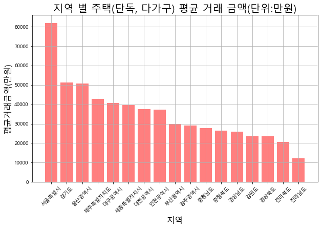

```python
data=df.groupby(["add_do"])[["price"]].mean().sort_values(by=['price'], axis=0, ascending=False)

plt.figure(1, figsize=(10, 6))
plt.title("지역 별 주택(단독, 다가구) 평균 거래 금액(단위:만원)",size=20)
plt.xlabel("지역", size=16)
plt.ylabel("평균거래금액(만원)", size=16)
plt.bar(data.index,data["price"],facecolor="red", alpha=0.5)
plt.xticks(rotation=45)
plt.grid(True)
```

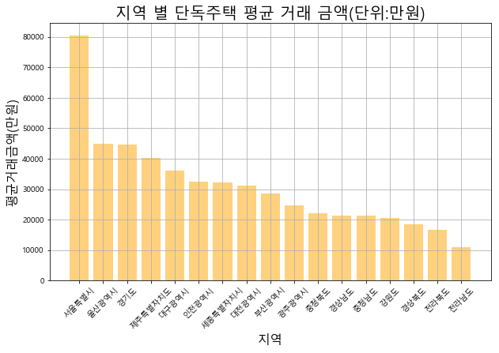

```python
data=df_single.groupby(["add_do"])[["price"]].mean().sort_values(by=['price'], axis=0, ascending=False)

plt.figure(1, figsize=(10, 6))
plt.title("지역 별 단독주택 평균 거래 금액(단위:만원)",size=20)
plt.xlabel("지역", size=16)
plt.ylabel("평균거래금액(만원)", size=16)
plt.bar(data.index,data["price"],facecolor="orange", alpha=0.5)
plt.xticks(rotation=45)
plt.grid(True)
```

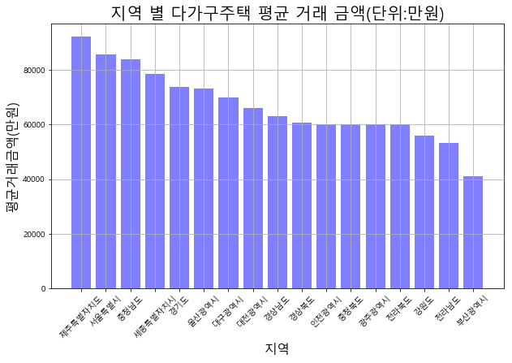

```python
data=df_multi.groupby(["add_do"])[["price"]].mean().sort_values(by=['price'], axis=0, ascending=False)

plt.figure(1, figsize=(10, 6))
plt.title("지역 별 다가구주택 평균 거래 금액(단위:만원)",size=20)
plt.xlabel("지역", size=16)
plt.ylabel("평균거래금액(만원)", size=16)
plt.bar(data.index,data["price"],facecolor="blue", alpha=0.5)
plt.xticks(rotation=45)
plt.grid(True)
```

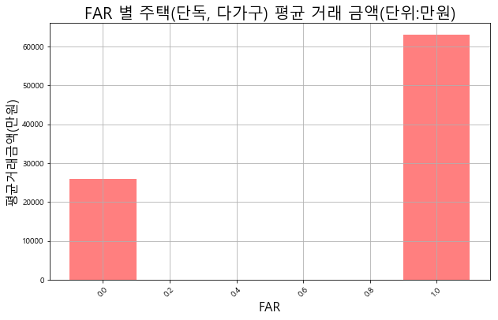

```python
data=df.groupby(["FAR"])[["price"]].mean().sort_values(by=['price'], axis=0, ascending=False)

plt.figure(1, figsize=(10, 6))
plt.title("FAR 별 주택(단독, 다가구) 평균 거래 금액(단위:만원)",size=20)
plt.xlabel("FAR", size=16)
plt.ylabel("평균거래금액(만원)", size=16)
plt.bar(data.index,data["price"],facecolor="red", alpha=0.5, width=0.2)
plt.xticks(rotation=45)
plt.grid(True)
```

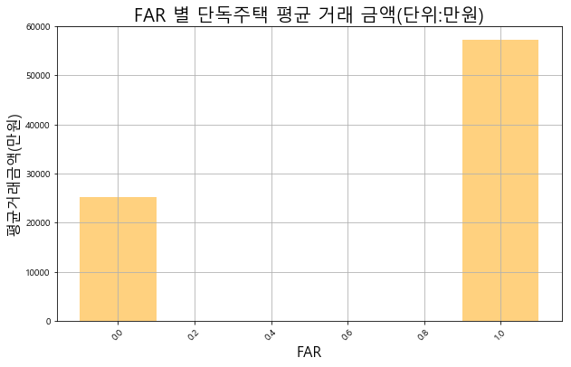

```python
data=df_single.groupby(["FAR"])[["price"]].mean().sort_values(by=['price'], axis=0, ascending=False)

plt.figure(1, figsize=(10, 6))
plt.title("FAR 별 단독주택 평균 거래 금액(단위:만원)",size=20)
plt.xlabel("FAR", size=16)
plt.ylabel("평균거래금액(만원)", size=16)
plt.bar(data.index,data["price"],facecolor="orange", alpha=0.5, width=0.2)
plt.xticks(rotation=45)
plt.grid(True)
```

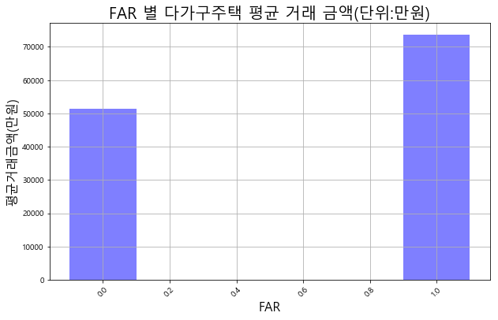

```python
data=df_multi.groupby(["FAR"])[["price"]].mean().sort_values(by=['price'], axis=0, ascending=False)

plt.figure(1, figsize=(10, 6))
plt.title("FAR 별 다가구주택 평균 거래 금액(단위:만원)",size=20)
plt.xlabel("FAR", size=16)
plt.ylabel("평균거래금액(만원)", size=16)
plt.bar(data.index,data["price"],facecolor="blue", alpha=0.5, width=0.2)
plt.xticks(rotation=45)
plt.grid(True)
```

### Scatter-plot

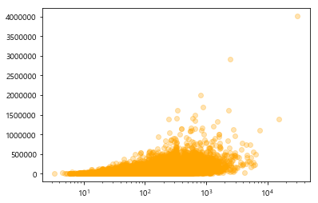

```python
data=df
plt.scatter(data["GFA"], data["price"], facecolor="orange", alpha=0.3)
plt.xscale("log")
```

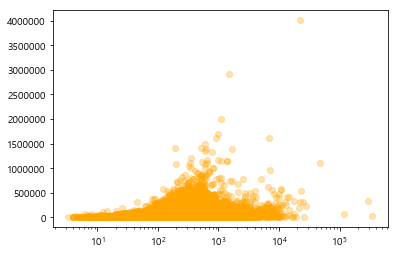

```python
data=df
plt.scatter(data["land_area"], data["price"],facecolor="orange", alpha=0.3)
plt.xscale("log")
```

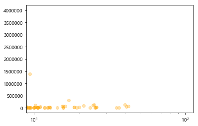

```python
data=df
plt.scatter(data["GFA"]/data["land_area"], data["price"],facecolor="orange", alpha=0.3)
plt.xscale("log")
```

## year_month

```python
data=df.groupby(["year_month"])[["price"]].mean().sort_values(by=['year_month'], axis=0, ascending=True)
```

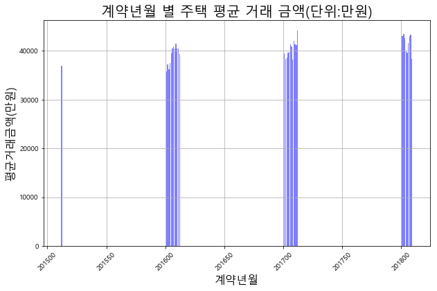

```python
plt.figure(1, figsize=(10, 6))
plt.title("계약년월 별 주택 평균 거래 금액(단위:만원)",size=20)
plt.xlabel("계약년월", size=16)
plt.ylabel("평균거래금액(만원)", size=16)
plt.bar(data.index,data["price"],facecolor="blue", alpha=0.5)
plt.xticks(rotation=45)
plt.grid(True)
```

```python
data.head()
```

| year_month | price |
| --- | --- |
| 201512 | 36976.200000 |
| 201601 | 35814.201696 |
| 201602 | 37197.702386 |
| 201603 | 36187.884465 |
| 201604 | 37489.123676 |